# As-a-Statistician-Sample Size Calculation

### 2-Sample Means, 1-Sided

$$\begin{array}{l}
H_{0}: \mu_{A}=\mu_{B} \\
H_{1}: \mu_{A}>\mu_{B}
\end{array}$$
where the ratio between the sample sizes of the two groups is
$$\kappa=\frac{n_{B}}{n_{A}}$$
Sample size and power, respectively:
$$\begin{array}{c}
n_{A}=\left(\sigma_{A}^{2}+\sigma_{B}^{2} / \kappa\right)\left(\frac{z_{1-\alpha}+z_{1-\beta}}{\mu_{A}-\mu_{B}}\right)^{2} \\
n_{B}=\kappa n_{A} \\
1-\beta=\Phi\left(\frac{\left|\mu_{A}-\mu_{B}\right| \sqrt{n_{A}}}{\sqrt{\sigma_{A}^{2}+\sigma_{B}^{2} / \kappa}}-z_{1-\alpha}\right)
\end{array}$$

### 2-Sample Means Non-Inferiority or Superiority

$$\begin{array}{l}
H_{0}: \mu_{A}-\mu_{B} \leq \delta \\
H_{1}: \mu_{A}-\mu_{B}>\delta
\end{array}$$
where $\delta$ is the superiority or non-inferiority margin and the ratio between the sample sizes of the two groups is
$$\kappa=\frac{n_{A}}{n_{B}}$$
Formulas of sample size and power, respectively:
$$\begin{array}{c}
n_{A}=\kappa n_{B} \\
n_{B}=\left(1+\frac{1}{\kappa}\right)\left(\sigma \frac{z_{1-\alpha}+z_{1-\beta}}{\mu_{A}-\mu_{B}-\delta}\right)^{2} \\
1-\beta=\Phi\left(z-z_{1-\alpha}\right)+\Phi\left(-z-z_{1-\alpha}\right) \quad, \quad z=\frac{\mu_{A}-\mu_{B}-\delta}{\sigma \sqrt{\frac{1}{n_{A}}+\frac{1}{n_{B}}}}
\end{array}$$

### 2-Sample Means Equivalence

$$\begin{array}{l}
H_{0}:\left|\mu_{A}-\mu_{B}\right| \geq \delta \\
H_{1}:\left|\mu_{A}-\mu_{B}\right|<\delta
\end{array}$$
where $\delta$ is the superiority or non-inferiority margin and the ratio between the sample sizes of the two groups is
$$\kappa=\frac{n_{1}}{n_{2}}$$
Formulas of sample size and power, respectively:
$$\begin{array}{c}
n_{A}=\kappa n_{B} \\
n_{B}=\left(1+\frac{1}{\kappa}\right)\left(\sigma \frac{z_{1-\alpha}+z_{1-\beta / 2}}{\left|\mu_{A}-\mu_{B}\right|-\delta}\right)^{2} \\
1-\beta=2\left[\Phi\left(z-z_{1-\alpha}\right)+\Phi\left(-z-z_{1-\alpha}\right)\right]-1 \quad, \quad z=\frac{\left|\mu_{A}-\mu_{B}\right|-\delta}{\sigma \sqrt{\frac{1}{n_{A}}+\frac{1}{n_{B}}}}
\end{array}$$

```r
muA=5
muB=4
delta=5
kappa=1
sd=10
alpha=0.05
beta=0.20
(nB=(1+1/kappa)*(sd*(qnorm(1-alpha)+qnorm(1-beta/2))/(abs(muA-muB)-delta))^2)
```

```
## [1] 107.0481
```

```r
ceiling(nB)
```

```
## [1] 108
```

```r
z=(abs(muA-muB)-delta)/(sd*sqrt((1+1/kappa)/nB))
(Power=2*(pnorm(z-qnorm(1-alpha))+pnorm(-z-qnorm(1-alpha)))-1)
```

```
## [1] 0.8000048
```

**SAS Implementation**

```
*** Equivalence Trial with Normal Endpoin;

%Macro EquivCI(nSims=1000, nPerGrp=200, ux=0, uy=1, delta=1.2, sigmax=1, sigmay=1.2, alpha=0.05);
  Data TwoGVars;
  Keep xMean yMean powerCI powerTest;
  powerCI=0; powerTest=0;
  Do iSim=1 To &nSims;
  xMean=0; yMean=0; s2x=0; s2y=0;
  Do iObs=1 To &nPerGrp;
  xNOR=Rannor(7362); xMean=xMean+xNor; s2x=s2x+xNor**2;
  yNOR=Rannor(2637); yMean=yMean+yNor; s2y=s2y+yNor**2;
  End;
  xMean=xMean*&sigmax/&nPerGrp+&ux;
  yMean=yMean*&sigmay/&nPerGrp+&uy;
  sp=((s2x*&sigmax**2+s2y*&sigmay**2)/(2*&nPerGrp-2))**0.5;
  se=sp/(&nPerGrp/2)**0.5;
  * CI method;
  ICW=Probit(1-&alpha)*se;
  If Abs(yMean-xMean)+ICW < &delta Then
  powerCI=powerCI+1/&nSims;
  *Two one-sided test method;
  T1=(xMean-yMean-&delta)/se;
  T2=(xMean-yMean+&delta)/se;
  If T1=Probit(1-&alpha) & T2>Probit(1-&alpha) Then
  powerTest=powerTest+1/&nSims;
  End;
  Output;
  Run;
  Proc Print Data=TwoGVars(obs=1); Run;
%Mend EquivCI;

Title “Equivalence test with normal response: Alpha under Ho”;
%EquivCI(nSims=10000, nPerGrp=1000, ux=0.2, uy=0, delta=0.2, sigmax=1, sigmay=1, alpha=0.05);

Title “Equivalence test with normal response: Power under Ha”;
%EquivCI(nSims=10000, nPerGrp=198, ux=0, uy=1, delta=1.2, sigmax=0.8, sigmay=0.8, alpha=0.05);
```

### T-Test using `pwr.t.test` or `pwr.t2n.test`

- `pwr.t.test`: Power calculations for t-tests of means (one sample, two samples and paired samples)
- `pwr.t2n.test`: Power calculations for two samples (different sizes) t-tests of means

```r
TTest <- function(alpha,mean,std,power,side){
  d <- mean/std
  # d: Effect size (Cohen's d) - difference between the means divided by the pooled standard deviation
  samplesize <- pwr.t.test(d=d, power=power, sig.level=alpha, type="two.sample",alternative=side)
  CI.Left  <- mean-qnorm(1-alpha/2)*std/sqrt(samplesize$n)
  CI.Right <- mean+qnorm(1-alpha/2)*std/sqrt(samplesize$n)
  CI <- paste("[",round(CI.Left,3), ",", round(CI.Right,3), "]", sep = "",collapse = NULL)
  results <- data.frame(alpha = alpha,
                      mean = mean,
                      sd = std,
                      power = samplesize$power,
                      side = samplesize$alternative,
                      n = samplesize$n,
                      CI = CI)
  return(results)
}

TTest(alpha = 0.05, mean = -0.42, std = 0.7, power = 0.8, side = "two.sided")
```

| alpha | mean | sd | power | side | n | CI |
| --- | --- | --- | --- | --- | --- | --- |
| 0.05 | -0.42 | 0.7 | 0.8 | two.sided | 44.58577 | [-0.625,-0.215] |

```r
TTest(alpha = 0.05, mean = -0.42, std = 0.748, power = 0.8, side = "less")
```

| alpha | mean | sd | power | side | n | CI |
| --- | --- | --- | --- | --- | --- | --- |
| 0.05 | -0.42 | 0.748 | 0.8 | less | 39.91355 | [-0.652,-0.188] |

### Test k Means

**1-Way ANOVA Pairwise, 2-Sided Equality using Bonferroni Adjustment**

In more general terms, we may have $k$ groups, meaning there are a total of $K \equiv\left(\begin{array}{c}k \\ 2\end{array}\right)=k(k-1) / 2$ possible pairwise comparisons. When we test $\tau \leq K$ of these pairwise comparisons, we have $\tau$ hypotheses of the form
$$\begin{array}{l}
H_{0}: \mu_{A}=\mu_{B} \\
H_{1}: \mu_{A} \neq \mu_{B}
\end{array}$$
where $\mu_{A}$ and $\mu_{B}$ represent the means of two of the $k$ groups, groups ‘A’ and ‘B’. We’ll compute the required sample size for each of the $\tau$ comparisons, and total sample size needed is the largest of these. In the formula below, $n$ represents the sample size in any one of these $\tau$ comparisons; that is, there are $n / 2$ people in the ‘A’ group, and $n / 2$ people in the ‘B’ group.

Formulas to compute sample size and power, respectively:
$$\begin{array}{c}
n=2\left(\sigma \frac{z_{1-\alpha /(2 \tau)}+z_{1-\beta}}{\mu_{A}-\mu_{B}}\right)^{2} \\
1-\beta=\Phi\left(z-z_{1-\alpha /(2 \tau)}\right)+\Phi\left(-z-z_{1-\alpha /(2 \tau)}\right) \quad, \quad z=\frac{\mu_{A}-\mu_{B}}{\sigma \sqrt{\frac{2}{n}}}
\end{array}$$

See more under multiple tests.

### Anova using `pwr.anova.test`

Perform power analysis on balanced one-way analysis of variance, where k is the number of groups, and n is the sample size in each group.

Now do a one-way analysis of variance for the five groups to achieve a power of 0.8, an **effect value** of 0.25, and a significance level of 0.05 to calculate the sample size required for each group

Where **effect value** is calculated using
$$f=\sqrt{\frac{\sum_{i=1}^k p_i \times (\mu_i - \mu)^2}{\sigma^2}}$$

```r
pwr.anova.test(k = 5, f = 0.25, sig.level = 0.05, power = 0.8)
```

```
##
##      Balanced one-way analysis of variance power calculation
##
##               k = 5
##               n = 39.1534
##               f = 0.25
##       sig.level = 0.05
##           power = 0.8
##
## NOTE: n is number in each group
```

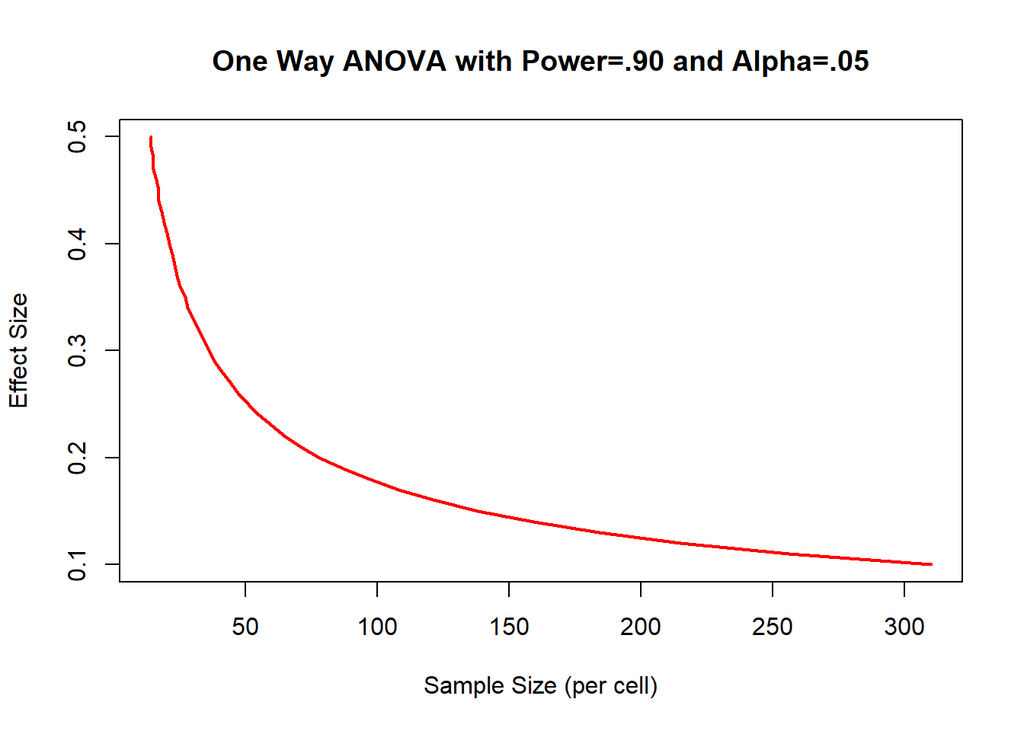

```r
# Sample sizes for detecting significant effects in a One-Way ANOVA

es <- seq(0.1, 0.5, 0.01)
nes <- length(es)
samsize <- NULL
for (i in 1:nes) {
    result <- pwr.anova.test(k = 5, f = es[i],
        sig.level = 0.05,
        power = 0.9)
    samsize[i] <- ceiling(result$n)
}
plot(samsize, es, type = "l", lwd = 2, col = "red",
    ylab = "Effect Size", xlab = "Sample Size (per cell)",
    main = "One Way ANOVA with Power=.90 and Alpha=.05")
```

### Average Bioequivalence

Pharmacokinetics (PK) is the study of the body’s absorption, distribution, metabolism, and elimination of a drug. An important outcome of a PK study is the bioavailability of the drug. The bioavailability of a drug is defined as the rate and extent to which the active drug ingredient or therapeutic moiety is absorbed and becomes available at the site of drug action. As bioavailability cannot be easily measured directly, the concentration of the drug that reaches the circulating bloodstream is taken as a surrogate. Therefore, bioavailability can be viewed as the concentration of the drug that is in the blood. Two drugs are bioequivalent if they have the same bioavailability.

> 药代动力学（PK）是人体对药物的吸收，分布，代谢和消除的研究。 PK 研究的一个重要结果是药物的生物利用度。 药物的生物利用度被定义为活性药物成分或治疗部分被吸收并在药物作用部位变得可用的速率和程度。由于不能轻易直接测量生物利用度，因此将到达循环血流的药物浓度作为替代指标。因此，生物利用度可以看作是血液中药物的浓度。如果两种药物具有相同的生物利用度，则它们是生物等效的

At the present time, average bioequivalence (ABE) serves as the current international standard for bioequivalence (BE) testing using a 2 × 2 crossover design (Chow and Liu, 2008). The PK parameters used for assessing ABE are area under the curve (AUC) and peak concentration (Cmax). The recommended statistical method is the two one-sided tests procedure to determine if the average values for the PK measures determined after administration of the T (test) and R (reference) products were comparable. This approach is termed ABE. It is equivalent to the so-called confidence interval method, which involves the calculation of a 90% confidence interval for the ratio of the averages (population geometric means) of the measures for the T and R products. To establish BE, the calculated confidence interval should fall within a BE limit, usually 80%–125% for the ratio of the product averages. The 1992 FDA guidance has also provided specific recommendations for logarithmic transformation of PK data, methods to evaluate sequence effects, and methods to evaluate outlier data. In practice, people also use parallel designs and the 90% confidence interval for nontransformed data. To establish BE, the calculated confidence interval should fall within a BE limit, usually 80%–120% for the difference of the product averages.

> 目前，平均生物等效性 (ABE) 是使用 2 × 2 交叉设计进行生物等效性 (BE) 测试的当前国际标准（Chow 和 Liu，2008 年）。用于评估 ABE 的 PK 参数是曲线下面积 (AUC) 和峰值浓度 (Cmax)。推荐的统计方法是两个单面测试程序，以确定在施用T（测试）和R（参考）产品后确定的PK度量的平均值是否可比。这种方法称为 ABE。它等效于所谓的置信区间方法，它涉及计算 T 和 R 产品度量的平均值（总体几何平均值）之比的 90% 置信区间。要建立 BE，计算出的置信区间应落在 BE 限值内，通常产品平均值的比率为 80% -125%。 1992 年的 FDA 指南还为 PK 数据的对数转换、评估序列效应的方法和评估离群数据的方法提供了具体建议。在实践中，人们还使用平行设计和未转换数据的 90% 置信区间。要建立 BE，计算的置信区间应落在 BE 限制内，通常产品平均值的差异为 80% -120%。

The hypothesis for ABE in a 2×2 crossover design with log-transformed data can be written as
$$\begin{array}{l}
H_{01}: \mu_{T}-\mu_{R} \leq-\ln 1.25 \\
H_{02}: \mu_{T}-\mu_{R} \geq \ln 1.25
\end{array}$$
The asymptotic sample size is given by (Chow et al., 2003 )
$$n=\frac{\left(z_{1-\alpha}+z_{1-\beta / 2}\right)^{2} \sigma_{1,1}^{2}}{2(\ln 1.25-|\varepsilon|)^{2}}$$
where the variance for the intrasubject comparison is estimated using
$$\hat{\sigma}_{1,1}^{2}=\frac{1}{n_{1}+n_{2}-2} \sum_{j=1}^{2} \sum_{i=1}^{n_{j}}\left(y_{i 1 j}-y_{i 2 j}-\bar{y}_{1 j}+\bar{y}_{2 j}\right)^{2}$$
$y_{i k j}$ is the log-transformed $\mathrm{PK}$ measure from the $i$ th subject in the $j$ th sequence at the $k$ th dosing period, and $\bar{y}_{k j}$ is the sample mean of the observations in the $j$ th sequence at the $k$ th period.

**Crossover Bioequivalence Trial SAS**

The $\mathrm{PK}$ parameter chosen for this bioequivalence test is a log-transformation of the 24 -hour AUC (i.e., the raw data is log-normal). Assume that the difference between the two formulations in $\log (\mathrm{AUC})$ is $\varepsilon=0.04$ and the standard deviation for the intrasubject comparison is $\sigma_{1,1}^{2}=0.55$ with $\alpha=0.05$ and $\beta=0.2$, the sample size per sequence is given by
$$n=\frac{(1.96+0.84)^{2}(0.55)^{2}}{2(0.223-0.04)^{2}}=36$$

```
%Macro Power2By2ABE(totalN=24, sWithin=0.355, uRatio=1);
  Data ABE; Keep sWithin uRatio n power;
  n=&totalN; sWithin=&sWithin; uRatio=&uRatio;
  * Err df for AB/BA crossover design;
  n2=n-2;
  t1=tinv(1-0.05,n-2); t2=-t1;
  nc1=Sqrt(n)*log(uRatio/0.8)/Sqrt(2)/sWithin;
  nc2=Sqrt(n)*log(uRatio/1.25)/Sqrt(2)/sWithin;
  df=Sqrt(n-2)*(nc1-nc2)/(2*t1);
  Power=Probt(t2,df,nc2)-Probt(t1,df,nc1);
  Run;
  Proc Print; Run;
%Mend Power2By2ABE;

%Power2By2ABE(totalN=58, sWithin=0.355, uRatio=1)
```

## Other Methods

### Odds Ratio

**Non-Inferiority or Superiority**

$$O R=\frac{p_{A}\left(1-p_{B}\right)}{p_{B}\left(1-p_{A}\right)}$$
The hypotheses to test are
$$\begin{array}{l}
H_{0}: \ln (O R) \leq \delta \\
H_{1}: \ln (O R)>\delta
\end{array}$$
where $\delta$ is the superiority or non-inferiority margin on the log scale, and the ratio between the sample sizes of the two groups is
$$\kappa=\frac{n_{A}}{n_{B}}$$
Formulas of sample size and power, respectively:
$$\begin{array}{l}
n_{A}=\kappa n_{B} \\ n_{B}=\left(\frac{1}{\kappa p_{A}\left(1-p_{A}\right)}+\frac{1}{p_{B}\left(1-p_{B}\right)}\right)\left(\frac{z_{1-\alpha}+z_{1-\beta}}{\ln (O R)-\delta}\right)^{2} \\
1-\beta=\Phi\left(z-z_{1-\alpha}\right)+\Phi\left(-z-z_{1-\alpha}\right) \quad, \quad z=\frac{(\ln (O R)-\delta) \sqrt{n_{B}}}{\sqrt{\frac{1}{\kappa p_{A}\left(1-p_{A}\right)}+\frac{1}{p_{B}\left(1-p_{B}\right)}}}
\end{array}$$

```r
pA=0.40
pB=0.25
delta=0.20
kappa=1
alpha=0.05
beta=0.20
(OR=pA*(1-pB)/pB/(1-pA)) # 2
```

```
## [1] 2
```

```r
(nB=(1/(kappa*pA*(1-pA))+1/(pB*(1-pB)))*((qnorm(1-alpha)+qnorm(1-beta))/(log(OR)-delta))^2)
```

```
## [1] 241.512
```

```r
ceiling(nB)
```

```
## [1] 242
```

```r
z=(log(OR)-delta)*sqrt(nB)/sqrt(1/(kappa*pA*(1-pA))+1/(pB*(1-pB)))
(Power=pnorm(z-qnorm(1-alpha))+pnorm(-z-qnorm(1-alpha)))
```

```
## [1] 0.800018
```

### Correlation

$$H_0: \rho \leq 0.25 \text { and } H_1: \rho>0.25$$

```r
pwr.r.test(r = 0.25, sig.level = 0.05, power = 0.9, alternative = "greater")
```

```
##
##      approximate correlation power calculation (arctangh transformation)
##
##               n = 133.2803
##               r = 0.25
##       sig.level = 0.05
##           power = 0.9
##     alternative = greater
```

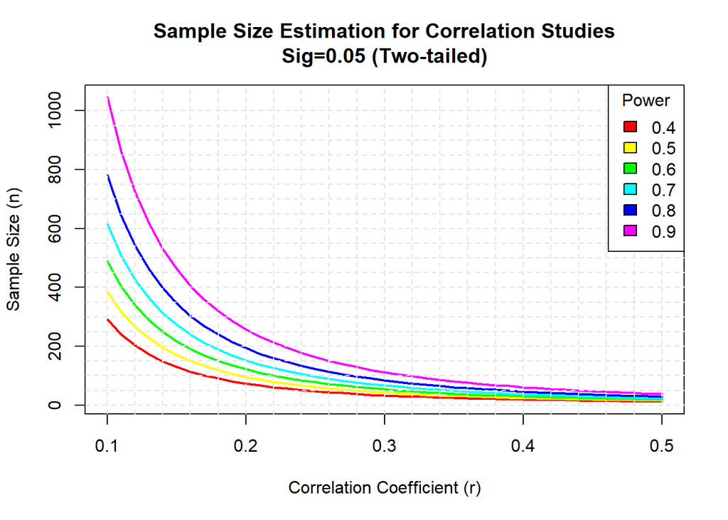

```r
## Generate a series of correlation coefficients and power values
library(pwr)
r <- seq(0.1, 0.5, 0.01)
nr <- length(r)
p <- seq(0.4, 0.9, 0.1)
np <- length(p)

# 获取样本大小
samsize <- array(numeric(nr * np), dim = c(nr, np))

for (i in 1:np) {
    for (j in 1:nr) {
        result <- pwr.r.test(n = NULL, r = r[j], sig.level = 0.05,
            power = p[i], alternative = "two.sided")
        samsize[j, i] <- ceiling(result$n)
    }
}

# 创建图形
xrange <- range(r)
yrange <- round(range(samsize))
colors <- rainbow(length(p))
plot(xrange, yrange, type = "n",
    xlab = "Correlation Coefficient (r)",
    ylab = "Sample Size (n)")

# 添加功效曲线
for (i in 1:np) {
    lines(r, samsize[, i], type = "l", lwd = 2, col = colors[i])
}
abline(v = 0, h = seq(0, yrange[2], 50), lty = 2,
    col = "grey89")
abline(h = 0, v = seq(xrange[1], xrange[2], 0.02),
    lty = 2, col = "grey89")
title("Sample Size Estimation for Correlation Studies\nSig=0.05 (Two-tailed)")
legend("topright", title = "Power", as.character(p),
    fill = colors)
```

### Correlated Binary Data: Ophthalmologic Studies

- Sample Size and Power Calculations with Correlated Binary Data
- [Sample Size Calculations for Ophthalmologic Studies](https://sci-hub.do/10.1001/archopht.1992.01080170112036)

It is assumed that one eye of each subject will be randomly assigned to receive eye-specific experimental treatments (such as extraocular muscle surgery), and the other eye will receive control treatments. This design will be very powerful when the correlation in the outcome measure between the eyes is reasonably high. However, this design assumes that the treatment of both eyes is pollution-free, and there is no generalized patient response, such as sympathetic ophthalmia. Such effects tend to obscure the differences between treatments.

**Two Eyes per Subject, Systemic Treatments**

Suppose that each patient will be random¬ ized to receive either a systemic, experimen¬ tal treatment (eg, oral steroids) or a placebo. Each subject will contribute two eyes to the analysis, and the within-subject outcomes are likely to be correlated. A measure of the correlation between eyes is the intraclass correlation coefficient, r, which has range of -1 to 1. Usually r is positive, indicating, for example, that the amount of visual field loss is high or low in both eyes, simultaneously. Most readers are familiar with the Pear¬ son Correlation Coefficient, commonly used and reported. Unlike the Pearson measure, the intraclass correlation coefficient is appli¬ cable only when both values for each subject are measured on the same scale and both have the same mean and SD.

- If all eyes are uncorrelated, a standard two-sample t-test can be used to detect group differences.
- However, if there is a correlation between the eyes, the test will give invalid results, thereby making the null hypothesis more rejected. 5 Just divide the standard t-statistic by the square root of (1 + r) to calculate a valid t-test. In order to calculate the number of eyes required for each treatment group, we can use the following formula to calculate and then simply multiply it by the number (1 + r)

$$n=(1+r)\left[2 s^{2}\left(z_{\alpha / 2}+z_{\beta}\right)^{2}\right] / d^{2}$$

**Mixed Single-Eye and Double-Eye Eligible Patients**

## Multiple test

Multiple comparisons and multiple testing procedures is their **reduced power**. Adjusted p-values are larger and simultaneous confidence intervals are wider, making it more difficult to reach firm conclusions. However, if you design your study with multiple inferences in mind, you can ensure that meaningful differences will be flagged as “statistically significant” with high probability, even when you use an MCP.

Power is **not so easily defined** in multiple testing situations as it is in single testing situations; there are multiple definitions, each of which is useful for different situations. Another difficulty lies in the complexity of the methods themselves: with complex closure-based methods, simply analyzing the data is difficult enough, let alone calculating power.

### Definitions of Power

In single testing situations, power is defined as the probability of correctly rejecting a false null hypothesis, that is, the probability of correctly “finding significance.” More precisely,

Power $=P\left(\right.$ reject $H_{0} \mid H_{0}$ is false).

To perform this calculation, you must specify the condition " $H_{0}$ is false" precisely.

In multiple testing and multiple comparisons applications, power is more complex since there are multiple parameters with multiple null hypotheses $H_{0 i}$. Definitions include

- Complete Power $=P\left(\right.$ reject all $H_{0 i}$ that are false)
- Minimal Power $=P\left(\right.$ reject at least one $H_{0 i}$ that is false)
- Individual Power $=P\left(\right.$ reject a particular $H_{0 i}$ that is false)
- Proportional Power = Expected Proportion of false $H_{0 i}$ that are rejected.

A simple example illustrates that these power measures vary greatly. Suppose you plan to test hypotheses $H_{1}, H_{2}, H_{3}$, and $H_{4}$ using independent tests whose powers (individually) are $0.5,0.5$, $0.8$, and $0.8$ respectively. Then

- Complete Power $=0.5 \times 0.5 \times 0.8 \times 0.8=0.16$
- Minimal Power $=1-(1-0.5) \times(1-0.5) \times(1-0.8) \times(1-0.8)=0.99$
- Individual Power $=0.5$ (say, assuming $H_{1}$ is the test of interest)
- Proportional Power $=(0.5+0.5+0.8+0.8) / 4=0.65$

**Complete Power**

Complete power appears the most attractive, since you obviously would like to reject all false hypotheses. However, compared to the rejection probability for an individual false hypothesis, it is relatively unlikely that you will reject all false hypotheses.

Nevertheless, complete power is required in some cases. For example, if a combination of two pharmaceutical products is to be approved for general use, it should be shown as superior to both individual products. Thus, both null hypotheses must be rejected. As discussed in a report from the International Conference for Harmonisation Guidelines on Statistical Principles for Clinical Trials (ICH, 1998), “If the purpose of the trial is to demonstrate effects on all of the designated primary variables, then there is no need for adjustment of the type I error, but the impact on type II error and sample size should be carefully considered.”

**Minimal Power**

Minimal power tells you the probability that you will find at least one significant result in your study, among hypotheses that are truly false. If your study only requires that at least one effect be demonstrated, then you should use minimal power.

This might occur, for example, in an **early phase of development of a pharmaceutical product**, where only a “proof of concept” is needed. If it can be shown that the product has at least some effect, then proof of concept is shown. Minimal power is also useful because it corresponds to the FWE rate: when the alternative differences all tend toward zero, the minimal power tends toward FWE. As with the complete power, computing the minimal power requires that you specify all the alternatives precisely; and again, while exact computations are infeasible, simulation yields results that are accurate enough for design purposes.

**Individual Power**

Among the various methods, individual power is the easiest to calculate, since it is just like “ordinary” power, except with multiplicity-adjusted critical values. Also, it can be calculated exactly, without resorting to simulations.

- Tests use critical points from MCPs: primary endpoint.
- Just interested in one hypothesis, then you can test that one without any multiplicity adjustment, and you can use ordinary power calculations.

### Bonferroni Tests (Individual Power)

Bonferroni $\alpha / k$ rather than the usual $\alpha$ is used for Test. Suppose you have a number $(k)$ of $t$ statistics of the form
$$t=\frac{\bar{y}-\bar{x}}{\hat{\sigma} \sqrt{2 / n}}$$
so that a Bonferroni rejection is given by
$$|t|>t_{1-\alpha^{\prime} / 2, d f e}$$
where $\alpha=\alpha / k$ and $d f e=2 n-2$. To calculate the rejection probability, use the fact that $t$ has the noncentral Student’s $t$ distribution with $d f e=2 n-2$ and noncentrality parameter
$$\Delta=(\delta / \sigma) \sqrt{n / 2}$$
where $\delta=\mu_{y}-\mu_{x}$.

```
%let MuDiff = 5;
%let Sigma = 10.0;
%let alpha = .05;
%let k = 4;
ods graphics on;
proc power;
 twosamplemeans
 meandiff = &MuDiff
 stddev = &Sigma
 alpha = %sysevalf(&alpha / &k)
 npergroup = 2 to 100 by 2
 power = .;
 plot x=n markers=analysis
 yopts=(ref=.8 crossref=yes);
run;
ods graphics off;
```

### Tukey’s method (Individual Power)

> in balanced one-way ANOVA for all pairwise comparisons

To detect a significant difference between $\mu_{i}$ and $\mu_{i^{\prime}}$, you must have
$$\left|t_{i, i^{\prime}}\right|=\left|\frac{\bar{y}_{i}-\bar{y}_{i^{\prime}}}{\hat{\sigma} \sqrt{2 / n}}\right|>c_{\alpha}$$
where
$$c_{\alpha}=\frac{q_{1-\alpha, g, g(n-1)}^{R}}{\sqrt{2}}$$
is the critical value used for Tukey’s method. To calculate these probabilities, again note that $t_{i, i^{\prime}}$ has the noncentral Student’s $t$ distribution with $d f e=g(n-1)$ and noncentrality parameter
$$\Delta=(\delta / \sigma) \sqrt{n / 2}$$
In order to compute the individual power for single-step Tukey tests, you need to specify the following:

- $d$ is the “meaningful difference”
- $\sigma$ is an estimate (or guess) of the within-group standard deviation of the response
- $g$ is the number of groups
- $n$ is the within-group sample size
- $\alpha$ is the desired FWE level

```
%IndividualPower(
MCP = RANGE, /* RANGE, DUNNETT2, DUNNETT1, OR MAXMOD */
g = 5, /* number of groups (exclude control for DUNNETT) */
d = 4, /* meaningful mean difference */
s = 3 /* estimate (guess) of standard deviation */
 );
```

### Dunnett’s Two-Sided Tests (Individual Power)

In order to detect a significant difference for a particular $\mu_{i}-\mu_{0}$ comparison when $\mu_{i}-\mu_{0}=d$. Again, the value $d$ is a specified number that is a “meaningful” difference in the particular problem context. Then you need
$$\left|t_{i 0}\right|=\left|\frac{\bar{y}_{i}-\bar{y}_{0}}{\hat{\sigma} \sqrt{2 / n}}\right|>q_{1-\alpha, g,(g+1)(n-1)}^{D 2}$$
to reject a hypothesis, and the power of the test, using the Individual Power definition, is the probability of this event. To calculate these probabilities, use the fact that the distribution of $\left|t_{i 0}\right|$ is non-central Student’s $t$ with $d f e=(g+1)(n-1)$ and noncentrality parameter as given above by $\Delta$.

For example, suppose that you have $g=6$ groups (excluding control), and you want to detect a difference of $\mu_{i}-\mu_{0}=5$ for a particular comparison, and guess that the standard deviation of the measurement is $\sigma=3.5$.

```
%IndividualPower(MCP = DUNNETT2,
 G = 6 ,
 D = 5 ,
 S = 3.5 );
```

### Combined Power %SimPower and %PlotSimPower

Complete, minimal, and proportional power involve several hypotheses simultaneously. As such, their calculations are complicated by the fact that they depend on the **specific alternative settings for all non-null hypotheses**, not just the alternative setting for a particular test of interest. Calculations are further complicated for complete and proportional power because they require the **multivariate non-central distribution of the test statistics**. The result of this complication is that calculating the power analytically is often infeasible for the combined power definitions. However, as in the case of computing the tests themselves, **simulation** can yield useful, if slightly imprecise, results.

```
%SimPower(method = <value> ,
 nrep = <number> ,
 n = <number> or <(n1,n2,...)> ,
 s = <number> ,
 FWE = <number> ,
 TrueMeans = <(m1,m2,...)> ,
 seed = <value> );
```

- METHOD is the multiple comparisons method, whether
  - all pairwise comparisons (METHOD = TUKEY, the default)
  - two-sided comparisons with control (METHOD = DUNNETT)
  - one-sided comparisons with a control (either METHOD = DUNNETTL or METHOD = DUNNETTU) or REGWQ
  - specify SIMULATE, so long as you also specify DIFF= to say what types of diffs, and you can also include STEPDOWN(TYPE= ), where the TYPE= variable is LOGICAL, LOGICAL(0), LOGICAL(1),…, or FREE
- NREP is the number of simulations, with 1000 as the default.
- N is the within-group sample size (if equal) or list of within-group sample sizes (if unequal).
- S is the underlying population standard deviation
- FWE is the desired FWE, with 0.05 as the default.
- TRUEMEANS lists the true group means.
- SEED is the seed value, with 0 (computer clock time) as the default.

%PlotSimPower macro to Simulate and Graph Combined Power

```
%PlotSimPower(method = <value> ,
 nrep = <number> ,
 s = <number> ,
 FWE = <number> ,
 TrueMeans = <(m1,m2,...)> ,
 seed = <value> ,
 stop = <value>/<number> ,
 target = <value> );
```

- STOP specifies the target value of a given type of power that will be used as a stopping criterion. The syntax is type/max, where type is either Complete, Minimal, or Proportional, and where max is a maximum power at which to stop the simulation. The default is Complete/0.9, meaning that the simulation stops at the sample size n for which the complete power is greater than or equal to 0.9 (with 95% confidence).
- TARGET is the desired power level. The default is 0.8.

#### **All Pairwise Comparisons**

```
%SimPower(TrueMeans = (10, 5, 5, 0, 0),
 S = 5 ,
 N = 10 ,
 Seed = 12345 );
```

#### **logically constrained step-down tests**

```
%SimPower(TrueMeans = (10,5,5,0,0) ,
 S = 5 ,
 N = 20 ,
 Seed = 12345 ,
 method = Simulate diff=All Stepdown(Type=Logical));
```

#### **DUNNETT Comparisons with a Control Two-Sided**

```
%SimPower(TrueMeans =(10,5,5,0,0),
 S = 5 ,
 N = 10 ,
 Seed = 12345 ,
 Method = DUNNETT );

*** Method = DUNNETTL One-Sided Comparisons with a Control
```

```
%PlotSimPower(TrueMeans = (10,5,5,0,0),
 S = 5 ,
 Seed = 12345 ,
 Method = Dunnett );
```

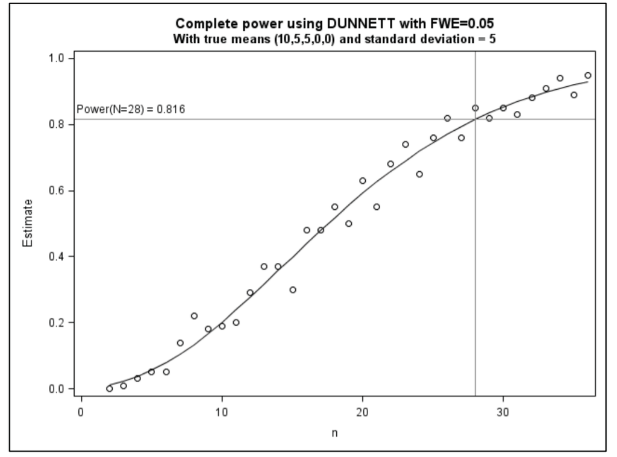

Figure: Plotting Simulated Complete Power of Two-Sided Comparisons with a Control

#### **Step-down Dunnett**

```
%SimPower(TrueMeans = (10,5,5,0,0) ,
 S = 5 ,
 N = 20 ,
 Seed = 12345 ,
 Method = SIMULATE DIFF=CONTROLL STEPDOWN);
```

### Dunnett Set up Close Tests in R

**Assumptions**:

1. The k treatment groups have identical treatment effect size.
2. The sample allocation ratio is pre-specified, and meanwhile the samples to be assigned to each of the k treatment groups are expected to be equal at size n.
3. The alternative hypotheses are one-sided.

With the violations assumption 2, the sample size could not be evaluated numerically, and with the violation of assumption 1 and 3, the evaluation of sample size needs great computational effort and thus not implemented. In the situation, simulation-based evaluation is suggested.

[output not shown]

## Time-To-Event Data

### Cox PH, 2-Sided Equality

The hazard ratio is then the ratio of the hazards between two groups. Letting $\theta$ represent the hazard ratio, the hypotheses of interest are
$$\begin{array}{l}
H_{0}: \theta=\theta_{0} \\
H_{1}: \theta \neq \theta_{0}
\end{array}$$
where $\theta_{0}$ is the hazard ratio hypothesized under the null hypothesis. $p_E$ is the overall probability of the event occurring within the study period. $p_{A}$ and $p_{B}$ are the proportions of the sample size allotted to the two groups, named ‘A’ and ‘B’

$$n=\frac{1}{p_{A} p_{B} p_{E}}\left(\frac{z_{1-\alpha / 2}+z_{1-\beta}}{\ln (\theta)-\ln \left(\theta_{0}\right)}\right)^{2}$$
$$1-\beta=\Phi\left(z-z_{1-\alpha / 2}\right)+\Phi\left(-z-z_{1-\alpha / 2}\right) \quad, \quad z=\left(\ln (\theta)-\ln \left(\theta_{0}\right)\right) \sqrt{n p_{A} p_{B} p_{E}}$$

```r
hr=2
hr0=1
pE=0.8
pA=0.5
alpha=0.05
beta=0.20
(n=((qnorm(1-alpha/2)+qnorm(1-beta))/(log(hr)-log(hr0)))^2/(pA*(1-pA)*pE))
```

```
## [1] 81.68207
```

```r
ceiling(n)
```

```
## [1] 82
```

```r
(Power=pnorm((log(hr)-log(hr0))*sqrt(n*pA*(1-pA)*pE)-qnorm(1-alpha/2)))
```

```
## [1] 0.8
```

### Log-Rank Tests for Competing Risks

[Logrank Tests Accounting for Competing Risks](https://ncss-wpengine.netdna-ssl.com/wp-content/themes/ncss/pdf/Procedures/PASS/Logrank_Tests_Accounting_for_Competing_Risks.pdf): Clinical trials are often designed to test the equality of two survival distributions. The two-sample t-test is not appropriate in this case because time-to-event data is usually not normally distributed and many individuals survive past the end of the study, resulting in censored observations. Instead, the logrank test is used to compare the two survival distributions because it is easy to apply and is usually more powerful than an analysis based simply on proportions. It compares survival across the whole spectrum of time, not at just one or two points, and accounts for censoring. When analyzing time-to-event data and calculating power and sample size, a complication arises when individuals in the study die from risk factors that are not directly related to the risk factor of interest. For example, a researcher may wish to determine if a new drug for some disease improves patient survival time when compared to a standard treatment. Therefore, the researchers would be interested to know how long each patient lives until he or she dies from the disease. However, during the course of the study, patients may also die from other risks such as myocardial infarction, diabetes, or even an accident. When a patient dies from one of these other risk factors, then the main event of interest cannot be observed, so the true time-to-event of the disease for that patient can never be determined. In this example the main event of interest would be death directly attributable to the disease. All of the other types of death are called competing risks.

**Assumptions**

The power and sample size calculations in the module for the logrank test are based on the following assumptions:

- Failure times for the event of interest and competing risks are independent.
- Failure times are exponentially distributed.
- Uniform entry of subjects into the trial during the accrual period

**Cumulative Incidence Function**

1. 在没有竞争风险且没有指数假设的情况下，在时间 $T_{0}$, 第 $i$ 组的兴趣事件为
   $$F_{e v, i}\left(T_{0}\right)=1-\exp \left\{-T_{0} \times h_{e v, i}\right\}$$
   where $h_{e v, i}$ is the hazard rate for the event of interest in group $i$. 注意, 在没有竞争风险的情况下
   $$F_{e v, i}\left(T_{0}\right)=1-S_{e v, i}\left(T_{0}\right)$$
   $S_{e v, i}\left(T_{0}\right)$ is the cumulative survival function
2. 在存在竞争风险的情况下，在时间 $T_{0}$ 的第 $i$ 组中 感兴趣事件的累积发生率函数为
   $$F_{e v, i}(T 0)=\frac{h_{e v, i}}{h_{e v, i}+h_{c r, i}}\left(1-\exp \left\{-T 0 \times\left(h_{e v, i}+h_{c r, i}\right)\right\}\right)$$
   $h_{c r, i}$ is the hazard rate for competing risks in group $i$. 竞争风险的累积发生率函数为
   $$F_{c r, i}(T 0)=\frac{h_{c r, i}}{h_{e v, i}+h_{c r, i}}\left(1-\exp \left\{-T 0 \times\left(h_{e v, i}+h_{c r, i}\right)\right\}\right)$$
   $h_{e v, i}$ is the hazard rate for the event of interest in group $i$.
3. 通过求解该方程组, 可从累积发生率计算 $i$ 组中的危险率
   $$\begin{array}{l}
   h_{e v, i}=F_{e v, i}(T 0) \times\left(\frac{-\ln \left(1-F_{e v, i}(T 0)-F_{c r, i}(T 0)\right)}{T 0 \times\left(F_{e v, i}(T 0)+F_{c r, i}(T 0)\right)}\right) \\
   h_{c r, i}=F_{c r, i}(T 0) \times\left(\frac{-\ln \left(1-F_{e v, i}(T 0)-F_{c r, i}(T 0)\right)}{T 0 \times\left(F_{e v, i}(T 0)+F_{c r, i}(T 0)\right)}\right)
   \end{array}$$

**Cumulative Survival Function**

$$\begin{array}{l}
S_{e v, i}(T 0)=\exp \left\{-T 0 \times h_{e v, i}\right\} \\
S_{c r, i}(T 0)=\exp \left\{-T 0 \times h_{c r, i}\right\}
\end{array}$$
The cumulative survival function is often estimated non-parametrically using the Kaplan-Meier curve. The hazard rates for the event of interest and competing risks in group $i$ are calculated from the cumulative survival functions as
$$\begin{array}{l}
h_{e v, i}=\left(\frac{-\ln \left(S_{e v, i}(T 0)\right)}{T 0}\right) \\
h_{c r, i}=\left(\frac{-\ln \left(S_{c r, i}(T 0)\right)}{T 0}\right)
\end{array}$$

**Hazard Ratio**

Hazard rate for the treatment group divided by the hazard rate for the control group.
$$H R=\left(\frac{h_{e v, 2}}{h_{e v, 1}}\right)$$

**Probability of Event**

With the risk rate of the event of interest and the competitive risk, the probability of observing the event of interest in the $i$ group$\operatorname{Pr}_{e v, i}$ 为:
$$\operatorname{Pr}_{e v, i}=\frac{h_{e v, i}}{h_{e v, i}+h_{c r, i}}\left(1-\frac{\exp \left\{-(T-R) \times\left(h_{e v, i}+h_{c r, i}\right)\right\}-\exp \left\{-T \times\left(h_{e v, i}+h_{c r, i}\right)\right\}}{R \times\left(h_{e v, i}+h_{c r, i}\right)}\right)$$
- $T$ is the total time of trial - $R$ is the accrual time. - The follow-up time is calculated as $T-R$. The overall probability of observing the event of interest during the study in both groups is given as
$$\operatorname{Pr}_{e v}=p_{1} \operatorname{Pr}_{e v, 1}+\left(1-p_{1}\right) \operatorname{Pr}_{e v, 2}$$
where $p_{1}$ is the proportion of subjects in the group $\$ 1, \$$ the control group.

**Number of Events**

- The total required number of events (for the event of interest), $E$
- The number of events in group $i$ is $E_{i}$
  $$\begin{array}{l}
  E=N \times \operatorname{Pr}_{e v} \\
  E_{i}=n_{i} \times \operatorname{Pr}_{e v, i}
  \end{array}$$

**Logrank Test Statistic**

The power and sample size formulas presented below are for the logrank test statistic, which is given by
$$L=\frac{\sum_{k=1}^{E}\left(I_{k}-\frac{Y_{1 i}}{Y_{1 i}+Y_{2 i}}\right)}{\left[\sum_{k=1}^{E}\left(\frac{Y_{1 i} Y_{2 i}}{\left(Y_{1 i}+Y_{2 i}\right)^{2}}\right)\right]^{-1 / 2}}$$

- $E$ 感兴趣类型的事件数
- $Y_{i j}$ 观察到的事件之前处于风险中的主体数prior to the $j^{\text {th }}$ in the $i^{\text {th }}$ group,
- $I_{k}$ is is a binary variable indicating whether the $k^{\text {th }}$ event of the type of interest is from group 1 or not.
- $L$ 遵循标准正态分布

**Power and Sample Size Calculations**

The power can be calculated using

$$z_{1-\beta}=(-) \sqrt{E \times p_{1}\left(1-p_{1}\right)} \log (H R)-z_{1-\alpha / 2}$$
- $p_{1}$ proportion of subjects in group 1, the control group - $E$ total number of events for the risk factor of interest

$$E=\left(\frac{1}{p_{1}\left(1-p_{1}\right)}\right) \times\left(\frac{z_{1-\alpha / 2}+z_{1-\beta}}{\log (H R)}\right)^{2}$$
The overall sample size can be computed from $E$ and $\operatorname{Pr}_{e v}$ as
$$N=\frac{E}{\operatorname{Pr}_{e v}}=\left(\frac{1}{p_{1}\left(1-p_{1}\right) \times \operatorname{Pr}_{e v}}\right) \times\left(\frac{z_{1-\alpha / 2}+z_{1-\beta}}{\log (H R)}\right)^{2}$$
The individual group sample sizes are calculated as
$$\begin{array}{l}
n_{1}=N \times p_{1} \\
n_{2}=N \times\left(1-p_{1}\right)
\end{array}$$

Considering the loss to Follow-Up, $W$ is the proportion lost to follow-up.
$$N_{\text {adjusted }}=\frac{N}{(1-W)}$$

**R Implementation**

```r
LogrankCR2 <- function(local, beta, S_ev1, S_ev2, S_cr, P1, P2, T, R, w, alpha_2){
  ## Quantile from standard normal distribution
  z_power <- qnorm(1-beta, mean = 0, sd = 1)
  z_local <- qnorm(1-local, mean = 0, sd = 1)

  ## Hazard Ratio
  H_ev1 <- -log(S_ev1)/T
  H_ev2 <- -log(S_ev2)/T
  H_cr <- -log(S_cr)/T
  HR <- H_ev2/H_ev1

  ## Probability of observing event of interest in the group
  P_ev1 <- (H_ev1/(H_ev1+H_cr))*(1-((exp(-(T-R)*(H_ev1+H_cr))-exp(-T*(H_ev1+H_cr)))/(R*(H_ev1+H_cr))))
  P_ev2 <- (H_ev2/(H_ev2+H_cr))*(1-((exp(-(T-R)*(H_ev2+H_cr))-exp(-T*(H_ev2+H_cr)))/(R*(H_ev2+H_cr))))
  P_ev <- P1*P_ev1+P2*P_ev2

  ## sample size without follow up lost
  N <- (1/(P1*P2*P_ev))*(((z_local+z_power)/log(HR))^2)

  N_Total <- N/t
  ## total number of events for the risk factor of interest
  E <- N_Total*P_ev
  Z_final_Power <- -sqrt(E*P1*(1-P1))*log(HR)-qnorm(1-alpha_2, mean = 0, sd = 1)
  final_Power <- pnorm(Z_final_Power, mean = 0, sd = 1)


  sample <- c(ceiling(N*P1*P_ev1), ceiling(N*P2*P_ev2),
              ceiling(N*P1), ceiling(N*P2),
              ceiling(N*P1)+ ceiling(N*P2),
              ceiling((1-t)*N*P1/t)+ceiling((1-t)*N*P2/t),
              round(final_Power*100,2),
              ceiling(N/(1-0.25)*P1), ceiling(N/(1-0.25)*P2),
              ceiling(N/(1-0.25)*P1)+ ceiling(N/(1-0.25)*P2),
              ceiling((1-t)*N/(1-0.25)*P1/t)+ ceiling((1-t)*N/(1-0.25)*P2/t))
  return(sample)
}

out <- function(final_alpha, IIIA, IIIB, IIIC_HR, IIIC_LR){
  alpha <- 0.0083
  local <- alpha*log(1+(exp(1)-1)*t)
  out_table <-  rbind(LogrankCR2(local=local, beta=0.1, S_ev1 = IIIA,    S_ev2=0.90,    S_cr=0.95, P1=0.4, P2=0.6, T=5.0000000001, R=0.0000000001, w=0.25, alpha_2=final_alpha),
                      LogrankCR2(local=local, beta=0.1, S_ev1 = IIIB,    S_ev2=0.90,    S_cr=0.95, P1=0.6, P2=0.4, T=5.0000000001, R=0.0000000001, w=0.25, alpha_2=final_alpha),
                      LogrankCR2(local=local, beta=0.1, S_ev1 = IIIC_HR, S_ev2=IIIC_LR, S_cr=0.95, P1=0.9, P2=0.1, T=5.0000000001, R=0.0000000001, w=0.25, alpha_2=final_alpha))
  out_table <- as.data.frame(out_table)
  colnames(out_table) <- c("Event HR","Event LR","NIA HR","NIA LR","NIA","NRc","Power","FU HR","FU LR", "FU IA", "FU Rc")
  sum <- colSums(out_table)
  sum[c(1,2,3,4,7,8,9)] <- NA
  out_table <- rbind(out_table,sum)
  return(out_table)
}


### If interim analysis is required
library("rpact")
design <- getDesignGroupSequential(sided = 1, alpha = 0.0083,
                                   informationRates = c(500/600, 1),
                                   typeOfDesign = "asP")
library("knitr")
t=500/700
kable(out(0.003544, 0.650, 0.642, 0.521, 0.9),
      caption = "Sample size calculation for Scenario 2.2 t= 500/700")
```

Sample size calculation for Scenario 2.2 t= 500/700

| Event HR | Event LR | NIA HR | NIA LR | NIA | NRc | Power | FU HR | FU LR | FU IA | FU Rc |
| --- | --- | --- | --- | --- | --- | --- | --- | --- | --- | --- |
| 21 | 9 | 61 | 92 | 153 | 62 | 96.02 | 82 | 122 | 204 | 82 |
| 25 | 5 | 69 | 46 | 115 | 47 | 96.02 | 92 | 62 | 154 | 62 |
| 47 | 2 | 99 | 11 | 110 | 45 | 96.02 | 132 | 15 | 147 | 59 |
| NA | NA | NA | NA | 378 | 154 | NA | NA | NA | 505 | 203 |

## Estimation in diagnostic test

Source [Sample size estimation in diagnostic test studies of biomedical informatics](https://www.sciencedirect.com/science/article/pii/S1532046414000501#s0030)

### Adequate sensitivity/specificity

Determine the number of cases to estimate sensitivity $(\mathrm{Se})$ of new diagnostic test. Similarly, one may estimate specificity $(\mathrm{Sp})$. Since sensitivity (or specificity) is a proportion, for estimation of sensitivity (or specificity) alone when the diseased status is known, the formula for sampler size with $(1-\alpha) \%$ confidence level and with maximum marginal error of estimate of $d$ for constructing confidence interval of true value of sensitivity (or specificity) using normal approximation is driven as follows:
$$n=\frac{Z_{\frac{\alpha}{2}}^{2} \widehat{P}(1-\widehat{P})}{d^{2}}$$
Simply one can drive the proportion of cases to controls as follows
$$\frac{n_{\text {casss }}}{n_{\text {coutrols }}}=\frac{\text { Prev }}{1-\text { Prev }}$$
Thus, the total sample sizes based on sensitivity and specificity respectively are
$$n_{\mathrm{Se}}=\frac{Z_{\frac{\alpha}{2}}^{3} \widehat{\operatorname{Se}}(1-\widehat{\mathrm{Se}})}{d^{2} \times \mathrm{Prev}}$$
$$n_{\mathrm{Sp}}=\frac{Z_{\frac{\alpha}{2}}^{2} \widehat{\operatorname{Sp}}(1-\widehat{\mathrm{Sp}})}{d^{2} \times(1-\mathrm{Prev})}$$

For example, if the Se is primary interested in diagnostic screening purpose and lets the pre-determined values of Se and prevalence of disease as 80% and 10% respectively. In order the maximum marginal error of estimate does not exceed from 7% with 95% confidence level, the total required sample size can be driven by plugging the above values as follows:
$$n_{\mathrm{Se}}=\frac{1.96^{2} \times 0.8 \times 0.20}{0.07^{2} \times 0.10}=1254$$

**R Implementation with Person CI**

```r
library(DescTools)
library(dplyr)
library(tibble)

SE_v <- seq(0.85,0.95, by = 0.01)
SP_v <- seq(0.90,0.97, by = 0.01)
SampleSize <- expand.grid(SE_v,SP_v)
names(SampleSize) <- c("SE_v","SP_v")

### the maximum marginal error of estimate does not exceed from 5% with 95% confidence level
d_SE <- 0.05
d_SP <- 0.05

SampleSize_table <- SampleSize %>%
  mutate(
    ### prevalence for COVID cases is 1/3
    n_SE = ceiling((qnorm(0.025)^2 * SE_v*(1-SE_v))/(d_SE^2 * 1/3)),
    ### prevalence for non COVID cases is 1-1/3
    n_SP = ceiling((qnorm(0.025)^2 * SP_v*(1-SP_v))/(d_SP^2 * (1-1/3))),
    N = n_SE)

### Calculation the CI based on clopper-pearson method
SampleSize_table$LL = round(as.data.frame(BinomCI(SampleSize_table$N*SampleSize_table$SE_v,
                                               SampleSize_table$N, conf.level = 0.975, sides = c("left"), method = c( "clopper-pearson"),tol = 0.0001))[2],3)
SampleSize_table$UL = as.data.frame(BinomCI(SampleSize_table$N*SampleSize_table$SE_v,
                                            SampleSize_table$N, conf.level = 0.975, sides = c("left"),  method = c( "clopper-pearson"),tol = 0.0001))[3]

knitr::kable(SampleSize_table[1:5,])
```

| SE_v | SP_v | n_SE | n_SP | N | LL | UL |
| --- | --- | --- | --- | --- | --- | --- |
| 0.85 | 0.9 | 588 | 208 | 588 | 0.819 | 1 |
| 0.86 | 0.9 | 556 | 208 | 556 | 0.828 | 1 |
| 0.87 | 0.9 | 522 | 208 | 522 | 0.838 | 1 |
| 0.88 | 0.9 | 487 | 208 | 487 | 0.848 | 1 |
| 0.89 | 0.9 | 452 | 208 | 452 | 0.857 | 1 |

### Testing sensitivity (or specificity)

**Sample size for testing sensitivity (or specificity) of single diagnostic test**

Suppose $P_{0}$ denote the pre-determined value of sensitivity or specificity of new diagnostic test. In comparing the test’s accuracy to fixed value of $P_{0}$, the null and alternative hypothesis is
$$\mathrm{H}_{0}: \mathrm{Se}=P_{0}$ versus $\mathrm{H}_{1}: \mathrm{Se} \neq P_{0}$ (or $\left.\mathrm{Se}=P_{1}\right)$$
where $P_{1}$ is the value of sensitivity (or specificity) under alternative hypothesis. Using normal approximation as a general rule, Z-score under the null and alternative hypothesis can defined and thus the required sample size for cases is driven as follows:

$$n=\frac{\left[Z_{\frac{\alpha}{2}} \sqrt{P_{0}\left(1-P_{0}\right)}+Z_{\beta} \sqrt{P_{1}\left(1-P_{1}\right)}\right]^{2}}{\left(P_{1}-P_{0}\right)^{2}}$$

**Sample size for comparing the sensitivity (or specificity) of two diagnostic tests**

For studies comparing sensitivity and/or specificity of two tests of unpaired design. In comparing the diagnostic accuracy of two alternative tasks for two independent samples, suppose $P_{1}$ and $P_{2}$ denote the expected proportion (Se or Sp) of two alternative diagnostic tests respectively. For testing hypothesis:
$$\mathrm{H}_{0}: \mathrm{P}_{1}=\mathrm{P}_{2} \ \text{versus} \ \mathrm{H}_{1} :P_{1} \neq P_{2}$$
, the required sample size with equal size based on normal approximation of binomial data with $1-\alpha$ confidence level and $1-\beta$ power is
$$n=\frac{\left[Z_{\frac{\alpha}{2}} \sqrt{2 \times \bar{P}(1-\bar{P})}+Z_{\beta} \sqrt{P_{1}\left(1-P_{1}\right)+P_{2}\left(1-P_{2}\right)}\right]^{2}}{\left(P_{1}-P_{2}\right)^{2}}$$
where $\bar{P}$ the average of $P_{1}$ and $P_{2}$ and $Z_{\alpha}, Z_{\beta}$ is are the standard normal $Z$ values corresponding to $\alpha$ and $\beta$ (the probability of type I and type II errors respectively).

### Likelihood ratio estimation

As we described when test yields positive or negative results, sensitivity and specificity are the two inherent indexes of accuracy, but LR that **combines the sensitivity and specificity of test as uni-dimensional index**, is a greater of interest. A test with higher LR^+ has a greater value of rule in the disease while a test with lower value of LR<sup>−</sup> has a higher value of rule out disease. These two indexes are particularly interesting in comparative studies of two or multiple tests. The test with greater value of LR^+ and lower values of LR<sup>−</sup> has more diagnostic abilities in the classification of true status of diseased and nondiseased. Thus, positive LR and negative LR play an important rule for clinical decision and they can be used in estimating sample size in diagnostic test.

Suppose $\widehat{P}_{1}$ and $\widehat{P}_{2}$ denote the **sensitivity and 1 -specificity** of a test respectively and $n_{1}$ and $n_{2}$ denote the sample size for diseased and nondiseased. The ratio estimator of $\mathrm{LR}^{\perp}=\frac{\widehat{P}_{1}}{\widehat{P}_{2}}$ is skewed and the logarithm transformation can be used to convert its distribution to normal approximately. Thus, $\log \frac{\widehat{P}_{1}}{\widehat{P}_{2}}$ can be assumed that asymptotically normally distributed with standard error of $\sqrt{\frac{1-\widehat{P}_{1}}{n_{1} \hat{P}_{1}}+\frac{1-\widehat{P}_{2}}{n_{2} \widehat{P}_{2}}}$ and therefore $(1-\alpha) \%$ confidence interval for $\log \left(\mathrm{LR}^{+}\right)$ is as follows:
$$\log \left(\mathrm{LR}^{+}\right)=\log \frac{\widehat{P}_{1}}{\widehat{P}_{2}} \pm Z_{\frac{\alpha}{2}} \sqrt{\frac{1-\hat{P}_{1}}{n_{1} \widehat{P}_{1}}+\frac{1-\widehat{P}_{2}}{n_{2} \widehat{P}_{2}}}$$
With the presumption of equal sample size for diseased and nondiseased (i.e. $\left.n_{1}=n_{2}=n\right)$, then the required sample size for each group of cases and controls can be calculated by solving the Eq. (6.10) as follows:
$$n=\frac{\left(Z_{\frac{\alpha}{2}} \sqrt{\frac{1-\hat{P}_{1}}{\hat{P}_{1}}+\frac{1-\hat{P}_{2}}{\hat{P}_{2}}}\right)^{2}}{\left(\log (\mathrm{LR}+)-\log \frac{\hat{P}_{1}}{\hat{P}_{2}}\right)^{2}}$$

In another condition, a diagnostic test may be useful, if negative LR is lower than a pre-determined value. Then, the sample size would be calculated based on the confidence bond of negative LR. Similarly, one could drive a confidence interval for $\mathrm{LR}^{-}$ as follows:
$$\log \left(\mathrm{LR}^{-}\right)=\left(\log \frac{\widehat{P}_{1}}{\widehat{P}_{2}} \pm Z_{\frac{\alpha}{2}} \sqrt{\frac{1-\widehat{P}_{1}}{n_{1} \widehat{P}_{1}}+\frac{1-\widehat{P}_{2}}{n_{2} \widehat{P}_{2}}}\right)$$
where $\widehat{P}_{1}=\mathrm{Sp}$ and $\widehat{P}_{2}=1-\mathrm{Se}$

### ROC index of accuracy

**Sample size for estimating accuracy index**

ROC curves show the trade off between sensitivity and specificity and the area under the curve (AUC) is considered as an index of accuracy. The AUC can be estimated parametric (binormal model) and nonparametric (Wilcoxon statistic) approaches. Both approaches allow estimating the sampling variability of AUC. In diagnostic studies, involving ROC analysis, for the purpose of estimating or testing AUC, the clinicians should decide the number of patients and controls needed in study protocol. Suppose a clinical researcher wishes to estimate the diagnostic accuracy as defined by AUC in which the marginal error of estimate (i.e. the difference between true AUC and its estimate) does not exceed from a pre-determined value of $d$ with $(1-\alpha) \%$ confidence level (e.g. $95 \%)$. Using normal approximation in constructing confidence interval for AUC, we have
$$Z_{\frac{\alpha}{2}} \mathrm{SE}(\widehat{\mathrm{AUC}}) \leqslant d$$
By squaring two sides of equation, then
$$Z_{\frac{\alpha}{2}}^{2} \operatorname{Var}(\widehat{\mathrm{AUC}})=d^{2}$$

**The variance of nonparametric AUC**

The variance of nonparametric AUC (Wilcoxon statistic) is estimated using the methods that proposed by Bamber [48] as
$$\operatorname{Var}(\widehat{\mathrm{AUC}})=\frac{\mathrm{AUC}(1-\mathrm{AUC})+\left(n_{1}-1\right)\left(Q_{1}-\mathrm{AUC}^{2}\right)+\left(n_{2}-1\right)\left(Q_{2}-\mathrm{AUC}^{2}\right)}{n_{1} n_{2}}$$
Hanley and McNeil [7] used exponential approximation to estimate $\mathrm{Q}_{1}$ and $\mathrm{Q}_{2}$ as
$$Q_{1}=\frac{\mathrm{AUC}}{2-\mathrm{AUC}} \quad$$
and
$$\quad Q_{2}=\frac{2 \mathrm{AUC}^{2}}{1+\mathrm{AUC}}$$
that allows one to estimate the variance of AUC and its SE. Thus, the variance of AUC under the null and also alternative hypothesis can be estimated easily. For studies with continuous test results $\operatorname{Var}(\widehat{\mathrm{AUC}})$ can be written approximately
$$\operatorname{Var}(\widehat{\mathrm{AUC}})=\frac{Q_{1}}{r}+Q_{2}-\operatorname{AUC}^{2}\left(\frac{1}{r}+1\right)$$
where $\mathrm{r}$ the ratio of sample size of controls to cases $\left(r=\frac{n_{2}}{n_{1}}\right)$.

**The variance of parametric AUC**

The two parameters of ROC curves based on binormal assumption are defined as $a=\frac{\mu_{2}-\mu_{1}}{\sigma_{1}}$ and $b=\frac{\sigma_{1}}{\sigma_{2}}$ where $\mu_{1}$ and $\sigma_{1}$ the mean and standard deviation of distribution for nondiseased and $\mu_{2}$ and $\sigma_{2}$ are for diseased distribution respectively. The area under curve with binormal model is $\mathrm{AUC}=\varphi\left[\frac{a}{1+b^{2}}\right]$ where $\varphi$ is the cumulative distribution function. Delta method can be used to estimate variance and SE of AUC. With an approximation when the ratio of SD is close to one (i.e. $b=1$ ) the binormal estimator of variance of $(\widehat{\mathrm{AUC}})$ is
$$\operatorname{Var}(\widehat{\mathrm{AUC}})=\left(0.0099 \times e^{-a^{2} / 2}\right) \times\left(\frac{5 a^{2}+8}{n_{2}}+\frac{a^{2}+8}{n_{1}}\right)$$
where $a=\varphi^{-1}(\mathrm{AUC}) \times 1.414$ and $n_{1}$ and $n_{2}$ are the sample size for nondiseased and diseased.

Lets $V(\widehat{\mathrm{AUC}})=n \operatorname{Var}((\widehat{\mathrm{AUC}})$. Thus, the required sample size for each group of nondiseased and diseased is
$$n=\frac{Z_{\frac{\alpha}{2}}^{2} V(\widehat{\mathrm{AUC}})}{d^{2}}$$

**Sample size for testing accuracy of quantitative diagnostic test of single modality**

$$\begin{array}{l}
\mathrm{H}_{0}: \mathrm{AUC}=\mathrm{AUC}_{0} \text { versus } \mathrm{H}_{1}: \mathrm{AUC} \neq \mathrm{AUC}_{0} \\
\text { (i. e. } \left.\mathrm{AUC}=\mathrm{AUC}_{1}\right)
\end{array}$$

$$n=\frac{\left[Z_{\frac{\alpha}{2}} \sqrt{V_{\mathrm{H} 0}(\widehat{\mathrm{AUC}})} \perp Z_{\beta} \sqrt{V_{\mathrm{Hl}}(\widehat{\mathrm{AUC}})}\right]^{2}}{\left[\mathrm{AUC}_{1}-\mathrm{AUC}_{0}\right]^{2}}$$

**Sample size for comparing accuracy of two diagnostic tests**

$$\mathrm{H}_{0}: \mathrm{AUC}_{1}=\mathrm{AUC}_{2}$ versus $\mathrm{H}_{1}: \mathrm{AUC}_{1} \neq \mathrm{AUC}_{2}$$

The required sample sizes for each group are driven as
$$n=\frac{\left[Z_{\frac{\alpha}{2}} \sqrt{V_{\mathrm{H} 0}\left(\widehat{\mathrm{AUC}}_{1}-\widehat{\mathrm{AUC}}_{2}\right)} \perp Z_{\beta} \sqrt{V_{\mathrm{H} 1}\left(\widehat{\mathrm{AUC}}_{1}-\widehat{\mathrm{AUC}}_{2}\right)}\right]}{\left[\mathrm{AUC}_{1}-\mathrm{AUC}_{2}\right]^{2}}$$
where
$$V\left(\widehat{\mathrm{AUC}}_{1}-\widehat{\mathrm{AUC}}_{2}\right)=n \operatorname{Var}\left(\widehat{\mathrm{AUC}}_{1}\right)+n \operatorname{Var}\left(\widehat{\mathrm{AUC}}_{2}\right)-2 n \operatorname{Cov}\left(\widehat{\mathrm{AUC}}_{1}, \widehat{\mathrm{AUC}}_{2}\right)$$